# Stats 102B - Homework 1

# Part 2: OLS Matrix Notation

## Task 2

The Chirot dataset which covers the 1907 Romanian Peasant Revolt:

```r
library(carData)
data(Chirot)
chirot_mat <- as.matrix(Chirot)
```

Already done for you: extract the commerce column and create our $\mathbf{X}$ matrix.

```r
t <- chirot_mat[, 1, drop = FALSE]  # response, keep as a matrix
x <- chirot_mat[, 2, drop = FALSE]  # commerce column, keep as matrix
X <- cbind(1, x)
colnames(X) <- c('1','commerce')
head(X)
```

```
##   1 commerce
## 1 1     13.8
## 2 1     20.4
## 3 1     27.6
## 4 1     18.6
## 5 1     17.2
## 6 1     21.5
```

- Use `lm()` to fit the rebellion intensity to matrix X (which has columns for a constant and commercialization). Make sure you only calculate the coefficient for the intercept once.

```r
m2.1 <- lm(t ~ X)
m2.1$coefficients
```

```
## (Intercept)          X1   Xcommerce
##  -2.8058274          NA   0.1066466
```

- Using only matrix operations, calculate and show the coefficient estimates. Verify that they match the estimates from `lm()`.

```r
w_2.1hat <- solve( t(X) %*% X) %*% t(X) %*% matrix(t)
w_2.1hat # They match!
```

```
##                [,1]
## 1        -2.8058274
## commerce  0.1066466
```

- Create another matrix (call it X_ct, the ct is for commerce and tradition) with three columns: a constant, variable commerce, variable tradition. Print the head of this matrix.

```r
t <- chirot_mat[, 1, drop = FALSE]  # response, keep as a matrix
a <- chirot_mat[, 2, drop = FALSE]  # commerce column, keep as matrix
b <- chirot_mat[, 3, drop = FALSE]  # tradition column, keep as matrix
X_ct <- cbind(1, a, b)
colnames(X_ct) <- c('1','commerce', 'tradition')
head(X_ct)
```

```
##   1 commerce tradition
## 1 1     13.8      86.2
## 2 1     20.4      86.7
## 3 1     27.6      79.3
## 4 1     18.6      90.1
## 5 1     17.2      84.5
## 6 1     21.5      81.5
```

- Using matrix operations, calculate and show the coefficient estimates of the model with the variables commerce and tradition.

```r
w_2.2hat <- solve( t(X_ct) %*% X_ct) %*% t(X_ct) %*% matrix(t)
w_2.2hat
```

```
##                   [,1]
## 1         -12.61148785
## commerce    0.09522408
## tradition   0.11992396
```

- Create another matrix (call it X_all) with all of the x variables (plus a constant). Print the head of this matrix. Using matrix operations, calculate and show the coefficient estimates of the model with all the variables.

```r
t <- chirot_mat[, 1, drop = FALSE]  # response, keep as a matrix
a <- chirot_mat[, 2, drop = FALSE]  # commerce column, keep as matrix
b <- chirot_mat[, 3, drop = FALSE]  # tradition column, keep as matrix
c <- chirot_mat[, 4, drop = FALSE]  # midpeasant column, keep as matrix
d <- chirot_mat[, 5, drop = FALSE]  # inequality column, keep as matrix
X_all <- cbind(1, a, b, c, d)
colnames(X_all) <- c('1','commerce', 'tradition', 'midpeasant', 'inequality')
head(X_all)
```

```
##   1 commerce tradition midpeasant inequality
## 1 1     13.8      86.2        6.2       0.60
## 2 1     20.4      86.7        2.9       0.72
## 3 1     27.6      79.3       16.9       0.66
## 4 1     18.6      90.1        3.4       0.74
## 5 1     17.2      84.5        9.0       0.70
## 6 1     21.5      81.5        5.2       0.60
```

```r
w_2.3hat <- solve( t(X_all) %*% X_all) %*% t(X_all) %*% matrix(t)
w_2.3hat
```

```
##                     [,1]
## 1          -12.919017967
## commerce     0.091140456
## tradition    0.116786574
## midpeasant  -0.003341668
## inequality   1.137969619
```

- Using matrix operations, calculate the fitted values for all three models. (No need to print out the fitted values.) Create plots of the fitted values vs the actual values for each model (there will be three plots). Be sure to provide a title for each plot.

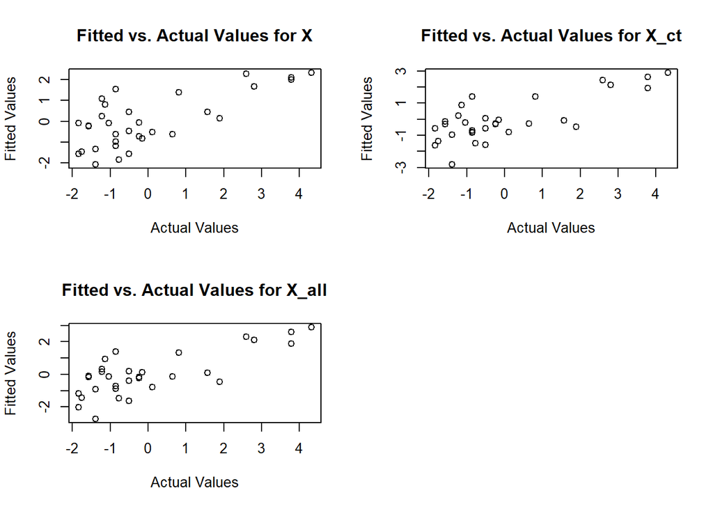

```r
# Our Fitted Values
t_2.1hat <- X %*% w_2.1hat
t_2.2hat <- X_ct %*% w_2.2hat
t_2.3hat <- X_all %*% w_2.3hat

# I used two ways of showing the Fitted vs Actual Values but still used 3 plots:
par(mfrow = c(2, 2))
plot(t, t_2.1hat, main = "Fitted vs. Actual Values for X",
     xlab = "Actual Values", ylab = "Fitted Values")
plot(t, t_2.2hat, main = "Fitted vs. Actual Values for X_ct",
     xlab = "Actual Values", ylab = "Fitted Values")
plot(t, t_2.3hat, main = "Fitted vs. Actual Values for X_all",
     xlab = "Actual Values", ylab = "Fitted Values")

# Black points are Actual Values
# Red points are Fitted Values
par(mfrow = c(2, 2))
```

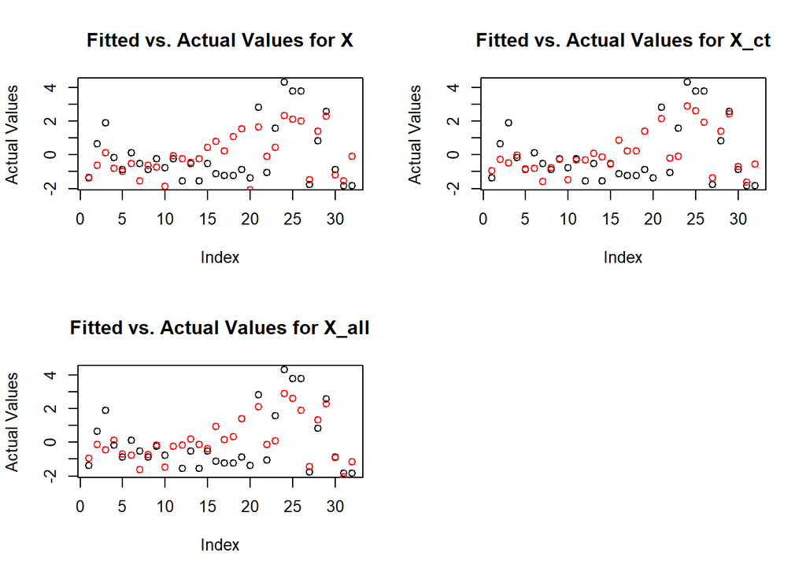

```r
plot(t, main = "Fitted vs. Actual Values for X", ylab = "Actual Values")
points(t_2.1hat, col = "red")
plot(t,main = "Fitted vs. Actual Values for X_ct", ylab = "Actual Values")
points(t_2.2hat, col = "red")
plot(t,main = "Fitted vs. Actual Values for X_all", ylab = "Actual Values")
points(t_2.3hat, col = "red")
```

- Now that you have calculated the columns of fitted values, find the Residual Sum of Squares and the R-squared values of the three models. Which model has the smallest RSS? (RSS is the sum of (actual - fitted)^2. R-sq is the correlation between actual and fitted, squared.)

```r
RSS_X <- sum((t - t_2.1hat)^2)
RSS_X_ct <- sum((t - t_2.2hat)^2)
RSS_X_all <- sum((t - t_2.3hat)^2)

R2_X <- cor(t, t_2.1hat)^2
R2_X_ct <- cor(t, t_2.2hat)^2
R2_X_all <- cor(t, t_2.3hat)^2

RSS_X
```

```
## [1] 47.5052
```

```r
RSS_X_ct
```

```
## [1] 41.43137
```

```r
RSS_X_all
```

```
## [1] 40.62534
```

```r
R2_X
```

```
##                [,1]
## intensity 0.5131222
```

```r
R2_X_ct
```

```
##                [,1]
## intensity 0.5753725
```

```r
R2_X_all
```

```
##                [,1]
## intensity 0.5836334
```

The smallest RSS is RSS_X_all, where it has all the variables tested. It would be the 3rd model with the lowest RSS.

# Part 3: Cross-Validation

The `ironslag` data set, and the linear model predicting the results of the chemical test based on the result from the easier magnetic test.

```r
library(DAAG)
x <- seq(10,40, .1)
```

## Task 3A

Create a plot showing the fitted line for each of the following models:

Linear: $y_n = w_0 + w_1 x_n + \epsilon_n$.

Quadratic: $y_n = w_0 + w_1 x_n + w_2 x_n^2 + \epsilon_n$

Exponential: $\log(y_n) = w_0 + w_1 x_n + \epsilon_n$, equivalent to $y_n = \exp(w_0 + w_1 x_n + \epsilon_n)$

log-log: $\log(y_n) = w_0 + w_1 \log(x_n) + \epsilon_n$

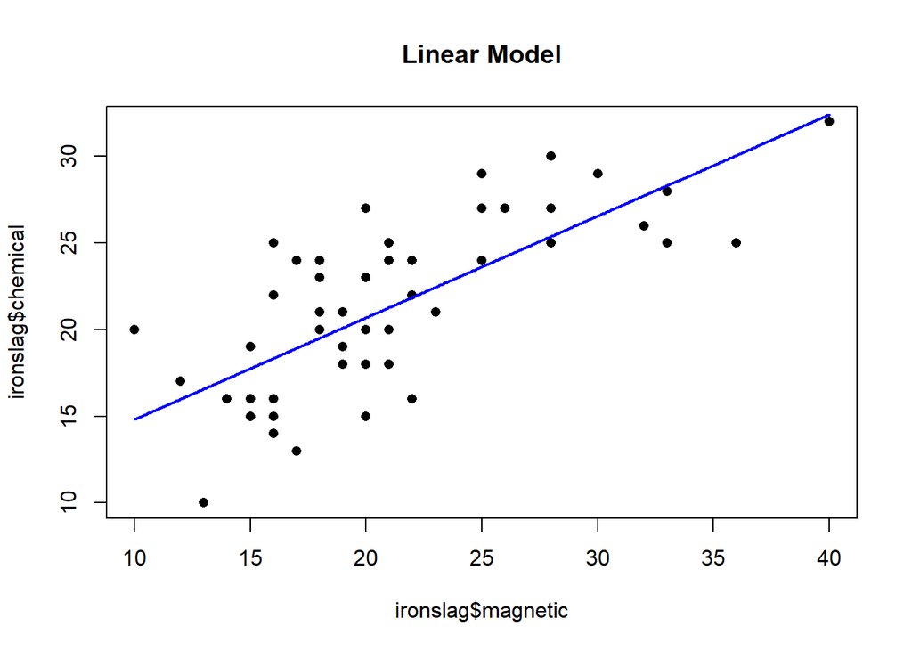

```r
# Standard Linear Model
L1 <- lm(chemical ~ magnetic, data = ironslag)
plot(ironslag$magnetic, ironslag$chemical, main = "Linear Model", pch = 16)
yhat1 <- L1$coef[1] + L1$coef[2] * x
lines(x, yhat1, lwd = 2, col = "blue")
```

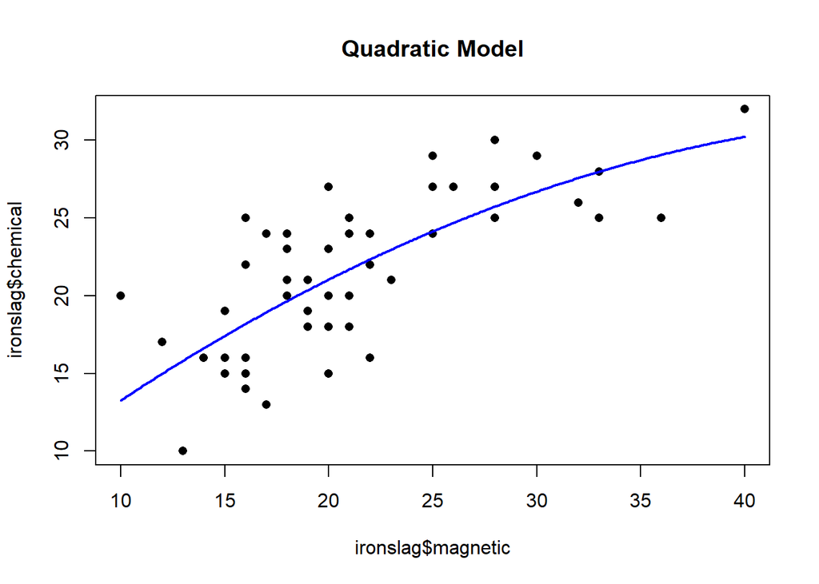

```r
# Quadratic Model
L2 <- lm(chemical ~ magnetic + I(magnetic^2), data = ironslag)
plot(ironslag$magnetic, ironslag$chemical, main = "Quadratic Model", pch = 16)
yhat2 <- L2$coef[1] + L2$coef[2] * x + L2$coefficients[3]*x^2 # must take power to 2
lines(x, yhat2, lwd = 2, col = "blue")
```

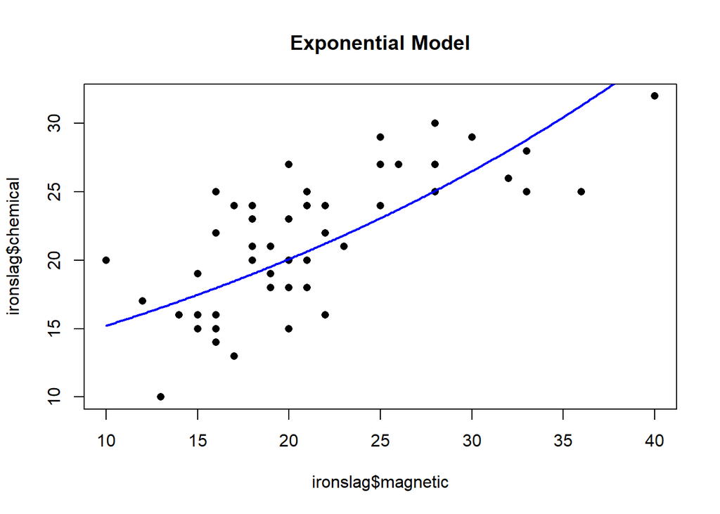

```r
# Exponential Model
L3 <- lm(log(chemical) ~ magnetic, data = ironslag)
plot(ironslag$magnetic, ironslag$chemical, main = "Exponential Model", pch = 16)
yhat3 <- L3$coef[1] + L3$coef[2] * x
lines(x, exp(yhat3), lwd = 2, col = "blue") # must take exp() of our y_hat
```

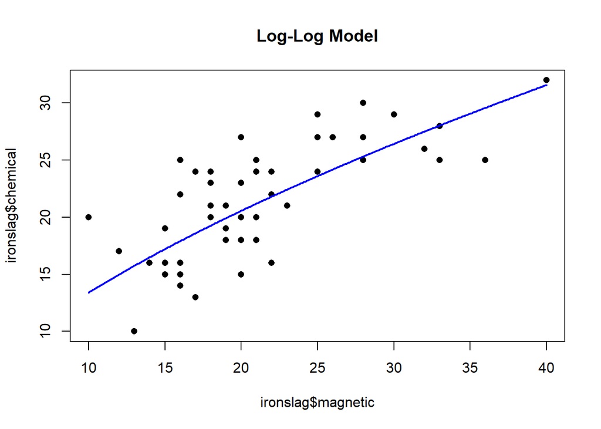

```r
# Log-Log Model
L4 <- lm(log(chemical) ~ log(magnetic), data = ironslag)
plot(ironslag$magnetic, ironslag$chemical, main = "Log-Log Model", pch = 16)
yhat4 <- L4$coef[1] + L4$coef[2] * log(x) # must take log() of our Predictor
lines(x, exp(yhat4), lwd = 2, col = "blue") # must take exp() of our y_hat
```

## Task 3B: Leave-one-out Cross validation

Code leave-one-out cross validation. Follow the guide and hints provided.

```r
error_model1 <- rep(NA, nrow(ironslag))
error_model2 <- rep(NA, nrow(ironslag))
error_model3 <- rep(NA, nrow(ironslag))
error_model4 <- rep(NA, nrow(ironslag))

for(i in seq_len(nrow(ironslag))){
  valid <- ironslag[i, ]
  train <- ironslag[-i, ]
  # m1 is our Linear Model
  m1 <- lm(chemical ~ magnetic, data = train)
  fitted1 <- predict(m1, valid)
  error_model1[i] <- (valid[, 1] - fitted1)^2
  # m2 is our Quadratic Model
  m2 <- lm(chemical ~ magnetic + I(magnetic^2), data = train)
  fitted2 <- predict(m2, valid)
  error_model2[i] <- (valid[, 1] - fitted2)^2
  # m3 is our Exponential Model
  m3 <- lm(log(chemical) ~ magnetic, data = train)
  fitted3 <- predict(m3, valid)
  error_model3[i] <- (valid[, 1] - exp(fitted3))^2 # have to take exp() of fitted
  # m4 is our Log-Log Model
  m4 <- lm(log(chemical) ~ log(magnetic), data = train)
  fitted4 <- predict(m4, valid)
  error_model4[i] <- (valid[, 1] - exp(fitted4))^2 # have to take exp() of fitted
}

mean(error_model1)
```

```
## [1] 12.44774
```

```r
mean(error_model2)
```

```
## [1] 13.02726
```

```r
mean(error_model3)
```

```
## [1] 13.58675
```

```r
mean(error_model4)
```

```
## [1] 12.47131
```

Compare the sizes of the cross validation error to help you decide which model does the best job of predicting the test cases.

*Model1* does the best job at predicting the test cases as it has the lowest MSE of 12.44774.

## Task 3C: Cross-validation with R

Use `glm()` to fit a model and `cv.glm()` to perform LOOCV.

```r
library(boot)
gL1 <- glm(chemical ~ magnetic, data = ironslag)
loocv1 <- cv.glm(ironslag, gL1)$delta[1]

gL2 <- glm(chemical ~ magnetic + I(magnetic^2), data = ironslag)
loocv2 <- cv.glm(ironslag, gL2)$delta[1]

# At this point, we have to start using the cost() function.
# Create our cost() function:
cost <- function(y, yhat) (exp(y) - exp(yhat))^2

gL3 <- glm(log(chemical) ~ magnetic, data = ironslag)
loocv3 <- cv.glm(ironslag, gL3, cost)$delta[1]

gL4 <- glm(log(chemical) ~ log(magnetic), data = ironslag)
loocv4 <- cv.glm(ironslag, gL4, cost)$delta[1]

loocv1
```

```
## [1] 12.44774
```

```r
loocv2
```

```
## [1] 13.02726
```

```r
loocv3
```

```
## [1] 13.58675
```

```r
loocv4
```

```
## [1] 12.47131
```

Your LOOCV estimates from `cv.glm()` should match your estimates when you coded your algorithm from scratch.

Based on your Cross Validation scores, which model seems to be the best?

*Model1* does the best job at predicting the test cases as it has the lowest LOOCV of 12.44774.

## Task 3D: Revisit Chirot

Use `glm()` to fit the three models to the Chirot data.

- model1: intensity ~ commerce
- model2: intensity ~ commerce + tradition
- model3: intensity ~ all other variables

Use `cv.glm()` to calculate the LOOCV scores to compare models. Which model would you select?

```r
attach(Chirot)

# model1 --> X
gL5 <- glm(intensity ~ commerce, data = Chirot)
loocv5 <- cv.glm(Chirot, gL5)$delta[1]

# model2 --> X_ct
gL6 <- glm(intensity ~ commerce + tradition, data = Chirot)
loocv6 <- cv.glm(Chirot, gL6)$delta[1]

# model3 --> X_all
gL7 <- glm(intensity ~ commerce + tradition + midpeasant + inequality,
           data = Chirot)
loocv7 <- cv.glm(Chirot, gL7)$delta[1]

loocv5
```

```
## [1] 1.714944
```

```r
loocv6
```

```
## [1] 1.591027
```

```r
loocv7
```

```
## [1] 1.693952
```

I would choose model X_ct (or *Model2* in this case) because it has the lowest LOOCV of 1.591027.

# Part 4: Using R’s `optim()` function

Synthetic data. Intercept of the population is 30. Slope of the population is 3.4.

Based on the provided sample, the OLS estimates are 35.266 and 3.382 for intercept and slope.

```r
x <- 1:100
set.seed(1)
e <- rnorm(100, 0, 40)
t <- 30 + 3.4 * x + e
coefs <- coef(lm(t ~ x))
print(coefs)  # if you use set.seed(1), this should be 35.266629, 3.381958
```

```
## (Intercept)           x
##   35.266629    3.381958
```

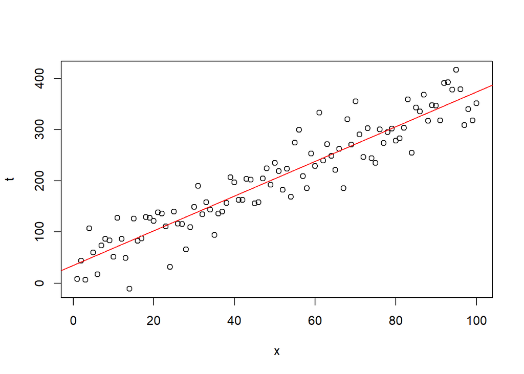

```r
plot(x, t)
abline(coef = coefs, col = "red")
```

## Task 4: Use `optim()` to minimize the sum of squared residuals in linear regression

Write your loss function as a function of the vector `par` that will return a single value: the sum of squared residuals.

```r
loss <- function(par) {
  t_hat <- par[1] + par[2]*x
  rss <- sum((t - t_hat)^2)
  return(rss)
}
```

The following chunk runs optim and returns the results. The arguments it takes in is the initial values of `par`, and the function you wrote which it will try to minimize. I have specified the method ‘BFGS’ which uses a version of gradient descent as the numeric algorithm to optimize the function.

```r
results <- optim(par = c(0,1), fn = loss, method = 'BFGS')
results$par # They match!
```

```
## [1] 35.266629  3.381958
```

Look at the results and the values of the parameters that minimize the loss function, they should match the coefficients estimated by `lm()`.